# Tree Pruning

## Recap: The Overfitting Problem

**Last class, we learned:**

- Decision trees split data recursively to minimize impurity
- Deep trees can memorize training data (overfitting)
- Need methods to control tree complexity

**Today’s Focus:**

- **Cost complexity pruning** algorithms
- **Cross-validation** for optimal tree size
- **Practical pruning** implementation

**Key Question:** How do we find the right tree size that generalizes well to new data?

## The Hitters Example: Demonstrating Overfitting

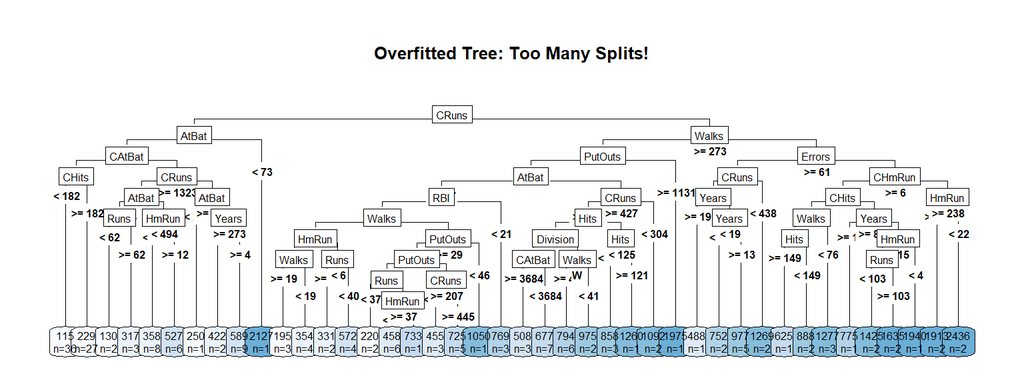

**The Problem is Clear:**

- **Training MSE:** \(3386\) (looks great!)
- **Test MSE:** \(1.33272\times 10^{5}\) (much worse!)
- **Tree size:** 42 terminal nodes (way too complex!)

**Question:** How do we find the “just right” tree size?

## The Solution: Cost Complexity Pruning

Too time consuming to go through all possible subtrees and calculate test peformance

**The Solution:** Cost complexity pruning automatically finds the optimal tree size

**Cost Complexity Criterion:** \(C_\alpha(T) = \sum_{m=1}^{|T|} \sum_{i: x_i \in R_m} (y_i - \hat{y}_{R_m})^2 + \alpha|T|\)

Where:

- \(|T|\) = number of terminal nodes (penalizes complexity)
- \(\alpha\) = penalty parameter (controls trade-off)
- First term = RSS (measures fit to data)
- Larger \(\alpha\) → smaller trees (more pruning)

**The Magic:** For every value of \(\alpha\), there’s an optimal subtree that minimizes this criterion!

**How it Works:**

1. Grow large tree \(T_0\) (like our overfitted Hitters tree)
2. For each \(\alpha\), find subtree that minimizes \(C_\alpha(T)\)
3. Use cross-validation to select best \(\alpha\)

## Applying Pruning to Our Hitters Tree

- `rpart` automatically creates a table `cptable` that calculates the optimal complexity values and performs cross validation

**Cross-Validation Results for Hitters:**

```
##       CP nsplit rel_error xerror   xstd     Selection
## 1 0.3588      0    1.0000 1.0204 0.1738
## 2 0.1787      1    0.6412 0.6936 0.1451
## 3 0.0456      2    0.4626 0.6441 0.1289  <- 1-SE Rule
## 4 0.0399      3    0.4170 0.6048 0.1203
## 5 0.0314      4    0.3771 0.5928 0.1203
## 6 0.0150      5    0.3456 0.5554 0.1199
## 7 0.0124      6    0.3307 0.5428 0.1200 <- Optimal CP
## 8 0.0100      7    0.3182 0.5617 0.1200
```

- **xerror:** Cross-validation error (relative to baseline)
- **xstd:** Standard error of cross-validation error

**Great news!** Cross-validation tells us the optimal tree size:

- **Optimal complexity parameter (cp):** 0.0124 (minimum xerror)
- **1-SE rule:** Choose simplest tree within 1 standard error of minimum
- **1-SE rule cp:** 0.0456 (simpler, often preferred!)

## Visualizing Cross-Validation Results

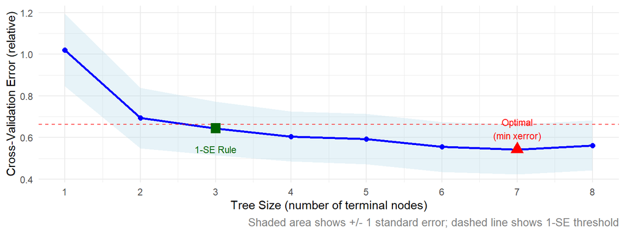

- **Left side:** Very simple trees (few nodes) have high error due to underfitting
- **Sweet spot:** The red triangle shows minimum cross-validation error (optimal complexity)
- **1-SE Rule:** The green square shows simpler tree within 1 standard error (preferred for interpretability)
- **Right side:** More complex trees show increasing error due to overfitting

**Key insight:** Cross-validation reveals the classic bias-variance tradeoff

- too simple causes underfitting, too complex causes overfitting!

## The Pruning Results: Before and After

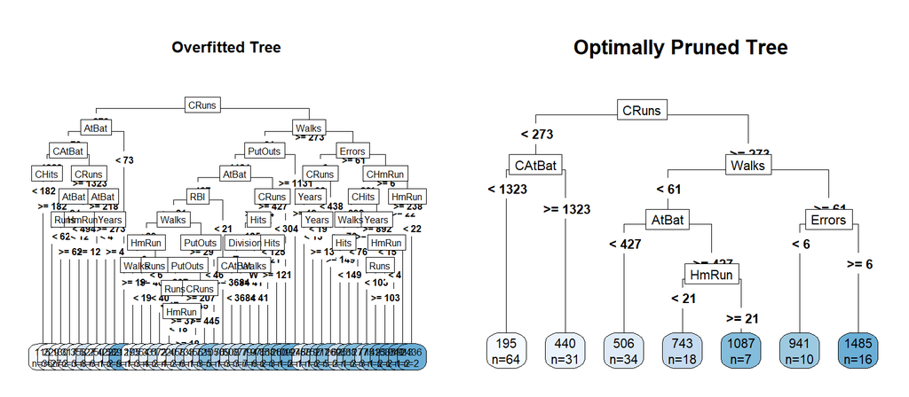

**Dramatic Improvement Using Optimal CP:**

- **Overfitted tree:** 42 terminal nodes (way too many!)
- **Optimally pruned tree:** 7 terminal nodes (CV-selected optimal size)
- **1-SE rule tree:** 3 terminal nodes (simplest within 1 SE)

**Result:** Using the cross-validation selected optimal CP gives us the theoretically best tree size!

## Comparing Performance: Full vs Pruned Trees

```
##                   Model Terminal_Nodes Test_MSE Interpretability
## 1       Overfitted Tree             42   133272         Very Low
## 2 Optimally Pruned Tree              7   125948           Medium
## 3        1-SE Rule Tree              3   108639             High
```

**Result:** Cross-validation guided pruning gives us better test performance than the overfitted tree!

## Understanding Variable Importance in Trees

**The Question:** Which variables are most important for predicting baseball salaries?

- Trees use variables at different **levels** (root vs. deep splits)
- Some variables may appear **multiple times** in the tree
- Variables used **higher** in the tree affect more observations
- Need a single metric to **rank** variable contributions

For each variable, importance = **sum of all improvements** it creates across all splits

\(\text{Importance}(X_j) = \sum_{\text{all nodes where } X_j \text{ splits}} \text{Improvement}\)

Where **Improvement** = reduction in impurity when splitting on variable \(X_j\)

```r
# Example: If CAtBat appears in 3 splits with improvements of 100, 50, 25
# Then Importance(CAtBat) = 100 + 50 + 25 = 175

# Variables used higher in tree (affecting more observations) get higher scores
# Variables used multiple times accumulate importance across splits
```

## Variable Importance Visualization

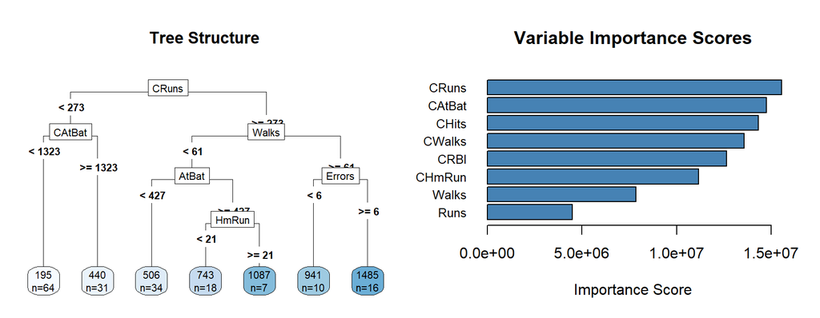

- **Root variable** gets highest priority - affects all observations
- Variables used in **multiple splits** accumulate importance across splits
- Scores come from all potential splits even though some are never used

**The Takeaway:** Importance scores reflect both **split position** (higher = more observations affected) and **frequency of use** throughout the tree!

## Practical Pruning Guidelines

**When to Prune:**

- Tree has many terminal nodes (>15 for modest datasets)
- Large difference between training and test error
- Tree is difficult to interpret
- Stakeholders need simple decision rules

**How to Choose Optimal Size:**

1. **Cross-validation:** Gold standard for pruning
2. **1-SE rule:** Choose simplest tree within 1 standard error of minimum
3. **Domain knowledge:** Sometimes simpler rules are preferred
4. **Validation set:** Alternative to CV for large datasets

**Common Mistakes:**

- Not using separate test set for final evaluation
- Over-relying on training error
- Ignoring interpretability requirements

## Pruning in Practice: Step-by-Step

```r
# Step 1: Build initial tree
my_tree <- rpart(Salary ~ . , data = hitters_train, method = "anova")

# Step 2: Examine cross-validation results
plotcp(my_tree)

# Step 3: Find optimal complexity parameter
cp_table <- my_tree$cptable
optimal_cp <- cp_table[which.min(cp_table[,"xerror"]), "CP"]

# Step 4: Prune the tree
pruned_tree <- prune(my_tree, cp = optimal_cp)

# Step 5: Evaluate on test set
test_predictions <- predict(pruned_tree, hitters_test)
test_mse <- mean((test_predictions - hitters_test$Salary)^2)
```

## Summary: Pruning Best Practices

**Key Algorithms:**

- **Cost complexity pruning:** Efficient way to find optimal subtrees
- **Cross-validation:** Unbiased estimate of test error
- **1-SE rule:** Choose simpler tree when performance is similar

**Practical Steps:**

1. Grow large initial tree
2. Use CV to find optimal complexity parameter
3. Prune tree to optimal size
4. Evaluate on separate test set
5. Consider interpretability requirements

**Tools in R:**

- `plotcp()` and `prune()` for `rpart` package
- `rpart.plot()` for visualization

## If Pruning Solves Overfitting, Are We Done?

**Unfortunately, No!** Even optimally pruned trees have significant limitations:

**The Core Problem: High Variance**

- **Instability:** Small changes in training data → completely different tree structure
- **Example:** Remove just 5 observations and you might get a totally different optimal tree!
- **Low Reliability:** Hard to trust predictions when the model is so unstable

**Other Limitations of Single Trees:**

- **Accuracy Ceiling:** Even the best pruned tree may not predict as well as we need
- **Binary Splits Only:** Trees struggle with smooth, continuous relationships
- **Limited by Single Model:** We’re putting all our eggs in one basket

**The Big Question:** Can we keep the interpretability benefits of trees while improving their predictive accuracy and stability?

**Good News:** Yes! We just need to think differently about how to use trees…

**Coming Up:** Methods that dramatically improve tree performance while maintaining their core strengths!